# Anova+post_hoc

Nadezhda Tsurikova

2023-01-24

```r
library(dplyr)
library(readxl)
library(tidyverse)
library(tidyr)
library(tibble)

soccer_general <- read_excel("soccer.xlsx")[, 2:6] %>%
    mutate(Position = as.factor(Position),
    Nationality = as.factor(Nationality),
    Age = as.numeric(Age),
    Height = as.numeric(Height)
) %>%
filter(Nationality %in% c("Spanish", "Italian", "German", "English", "Argentinian"))

set.seed(1)

soccer_wrk <- soccer_general[sample(1:nrow(soccer_general), 150), ] %>%
    mutate(Nationality = factor(Nationality))
```

```r
lm(Height~Position, data=soccer_wrk) %>% anova
```

```
## Analysis of Variance Table
##
## Response: Height
##            Df Sum Sq Mean Sq F value    Pr(>F)
## Position    3 1345.0  448.32   12.88 1.635e-07 ***
## Residuals 146 5082.1   34.81
## ---
## Signif. codes:  0 '***' 0.001 '**' 0.01 '*' 0.05 '.' 0.1 ' ' 1
```

Pr(>F) 1.635e-07(меньше 0.05), т.е. мы отвергаем нулевую гипотезу о том, что разницы между ростом и позицией нет.

F-тест Велша:

```r
oneway.test(Height ~ Position, data = soccer_wrk)
```

```
##
##  One-way analysis of means (not assuming equal variances)
##
## data:  Height and Position
## F = 15.44, num df = 3.00, denom df = 62.23, p-value = 1.288e-07
```

```r
library(multcomp)
mo <- lm(Height~Position, data=soccer_wrk)
hbw <- mo %>% glht (linfct = mcp(Position="Tukey"))
hbw %>% summary
```

```
##
##   Simultaneous Tests for General Linear Hypotheses
##
## Multiple Comparisons of Means: Tukey Contrasts
##
##
## Fit: lm(formula = Height ~ Position, data = soccer_wrk)
##
## Linear Hypotheses:
##                              Estimate Std. Error t value Pr(>|t|)
## Forward - Defender == 0        -1.718      1.339  -1.283  0.57138
## Goalkeeper - Defender == 0      5.258      1.513   3.474  0.00366 **
## Midfielder - Defender == 0     -4.218      1.193  -3.535  0.00297 **
## Goalkeeper - Forward == 0       6.976      1.679   4.156  < 0.001 ***
## Midfielder - Forward == 0      -2.500      1.397  -1.790  0.27918
## Midfielder - Goalkeeper == 0   -9.476      1.565  -6.056  < 0.001 ***
## ---
## Signif. codes:  0 '***' 0.001 '**' 0.01 '*' 0.05 '.' 0.1 ' ' 1
## (Adjusted p values reported -- single-step method)
```

Полученный анализ говорит о том, что статистически значимая разница в средних между ростом и положением на поле есть у Goalkeeper - Defender, Midfielder - Defender, Goalkeeper - Forward, Midfielder - Goalkeeper. Т.о. мы отвергает нулевую гипотезу о равенстве средних в группах.

```r
hbw %>% confint()
```

```
##
##   Simultaneous Confidence Intervals
##
## Multiple Comparisons of Means: Tukey Contrasts
##
##
## Fit: lm(formula = Height ~ Position, data = soccer_wrk)
##
## Quantile = 2.5918
## 95% family-wise confidence level
##
##
## Linear Hypotheses:
##                              Estimate lwr      upr
## Forward - Defender == 0       -1.7182  -5.1889   1.7525
## Goalkeeper - Defender == 0     5.2580   1.3355   9.1806
## Midfielder - Defender == 0    -4.2182  -7.3111  -1.1253
## Goalkeeper - Forward == 0      6.9762   2.6254  11.3270
## Midfielder - Forward == 0     -2.5000  -6.1206   1.1206
## Midfielder - Goalkeeper == 0  -9.4762 -13.5320  -5.4204
```

95% ДИ пересекают ноль только у Forward - Defender и Midfielder - Forward, т.е. с 95% вероятностью эти 2 пары будут охватывать истинное значение среднего

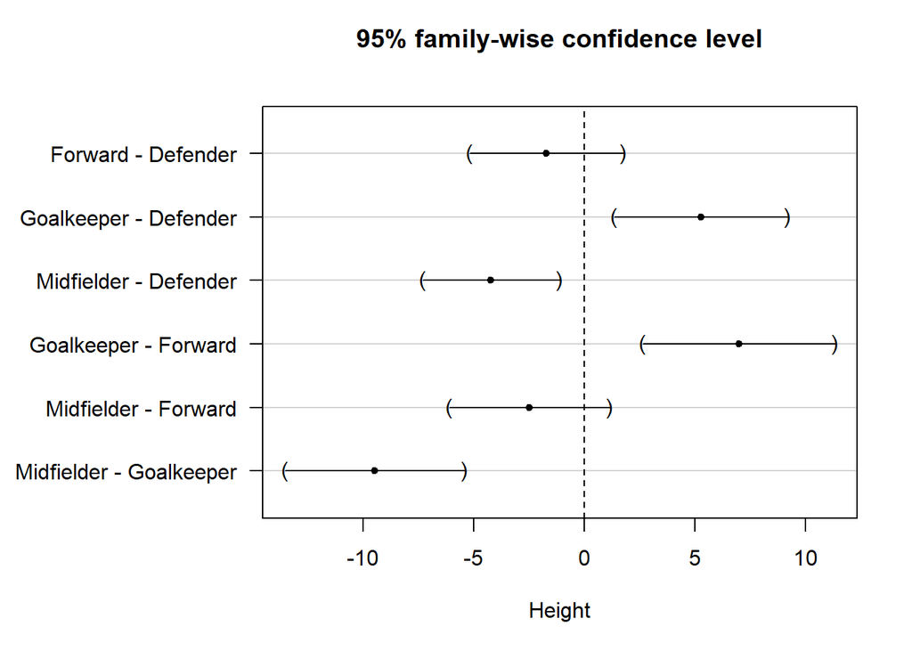

```r
par(mar=c(5,10,4,2)+0.1)
hbw %>% plot(xlab="Height")
```

В первом случае у нас были выявлены следующие пары с уровнем p-value < 0.05: Goalkeeper - Defender, Midfielder - Defender, Goalkeeper - Forward, Midfielder - Goalkeeper,

в случае оценки 95% ДИ было выявлено что пары Forward - Defender и Midfielder - Forward пересекают ноль.

```r
lm(Height~Nationality, data=soccer_wrk) %>% anova
```

```
## Analysis of Variance Table
##
## Response: Height
##              Df Sum Sq Mean Sq F value Pr(>F)
## Nationality   4  164.1  41.033    0.95 0.4371
## Residuals   145 6263.0  43.193
```

мы не можем отвергнуть нулевую гипотезу, так как Pr(>F) 0.4371 (т.е. разницы между ростом и командой не выявлено).

```r
holm_adj <- pairwise.t.test(soccer_wrk$Height, soccer_wrk$Position, p.adjust.method = "holm", pool.sd = FALSE)
print(holm_adj)
```

```
##
##  Pairwise comparisons using t tests with non-pooled SD
##
## data:  soccer_wrk$Height and soccer_wrk$Position
##
##            Defender Forward Goalkeeper
## Forward    0.29118  -       -
## Goalkeeper 0.00103  0.00118 -
## Midfielder 0.00099  0.29118 1.5e-07
##
## P value adjustment method: holm
```

Нулевая гипотеза: разница в среднем росте футболистов равна нулю. Разница в средних в каждой паре, кроме (Midfielder -Forward, Forward- Defender ) не равна нулю, следовательно мы отрицаем нулевую гипотезу для всех кроме пар Midfielder -Forward b Forward- Defender.

```r
BH_adj <- pairwise.t.test(soccer_wrk$Height, soccer_wrk$Position, p.adjust.method = "BH", pool.sd = FALSE)
print(BH_adj)
```

```
##
##  Pairwise comparisons using t tests with non-pooled SD
##
## data:  soccer_wrk$Height and soccer_wrk$Position
##
##            Defender Forward Goalkeeper
## Forward    0.29106  -       -
## Goalkeeper 0.00051  0.00059 -
## Midfielder 0.00051  0.17471 1.5e-07
##
## P value adjustment method: BH
```

Нулевая гипотеза: разница в среднем росте футболистов равна нулю. Разница в средних в каждой паре, кроме (Midfielder -Forward, Forward- Defender ) не равна нулю, следовательно мы отрицаем нулевую гипотезу для всех кроме пар Midfielder -Forward и Forward- Defender.